# Análisis de Componentes Principales de la información del Censo Nacional Agropecuario (DANE 2013 - 2014)

Reporte

Diana Galindo, Aníbal Montero y Javier Jácome

20 de marzo de 2018

# 1. Introducción

El grupo de Investigación y Desarrollo de la Dirección de Geoestadística realizó un estudio postcensal de los datos del Tercer Censo Nacional Agropecuario. Su objetivo fundamental fue caracterizar la agricultura familiar y la agricultura empresarial utilizando análisis de componentes principales y estadística espacial. El análisis de componentes principales permite, en conjuntos de datos con gran número de columnas, reducir la dimensionalidad para obtener unas pocas variables sintéticas que capturan buena parte de la información original. El análisis espacial se realizó sobre las variables sintéticas obtenidas y buscó encontrar patrones de asociación espacial entre veredas.

Por transparencia y reproductibilidad el trabajo se realizó en Rmarkdown, un lenguaje de escritura de texto que permite ejecutar código en R. De esta forma los cálculos intermedios en una investigación pueden ser puestos a disposición del público, para que quien quiera analizar los procesos, reproducir el contenido o utilizar segmentos del código para otros propósitos pueda hacerlo libremente. A continuación se presenta en este forma la parte de la investigación correspondiente al análisis de componentes principales.

# 2. Instalación de paquetes

Se instalan los paquetes necesarios para el análisis. Se hace de tal manera que sólo se instalen aquellos que no lo estuvieran previamente.

```r
# Vector con paquetes a cargar
paquetes<-c("ade4","corrplot","factoextra","FactoMineR","foreign","ggplot2","gridExtra","Hmisc","RColorBrewer","reshape2","RPostgreSQL","knitr","openxlsx","NbClust","DT","d3heatmap","heatmaply","sf","viridis","leaflet","pander","VIM","plotly")

# Vector con los paquetes no instalados
instalaciones<-paquetes[!paquetes %in% installed.packages()]

# Iteración para descargar los paquetes sin instalar
for(libs in instalaciones) install.packages(libs)

# carga de paquetes
sapply(paquetes,require,character=TRUE)

# Cambiar según ubicación de librería Rtools en el equipo de trabajo
Sys.setenv("R_ZIPCMD"='C:/Rtools/bin/zip.exe')
```

# 3. Importación de datos

El proceso para consolidar los datos por vereda y la selección temática de variables se explica en detalle en el Documento técnico del estudio.

A continuación se importan las variables del 3er CNA que fueron previamente seleccionadas para el análisis. Estas habían sido almacenadas en un archivo de extensión *rda*. La ventaja de este procedimiento es que permite importar la matriz de datos como un objeto de R directamente. En este caso se llama *resultado*.

```r
# Del Script 20171220 se toma el objeto "resultado"
load(file = "//dg_est103/INVESTIGACION/ESTUDIOS_POST_CNA/DESARROLLO/ACP/V5/resultado.rda")
```

Las variables fueron renombradas para facilitar su visualización. La siguiente tabla muestra las variables que se van a incluir en el ACP, su nombre original y el asignado para realizar el análisis en R.

| Nro. | Inicial | Nombre en R | Detalle (por vereda) |
| --- | --- | --- | --- |
| 1 | cod_vereda | cod_vereda | Código de vereda |
| 5 | p117_por_maquinaria | p_maq | Proporción de UPAS que cuentan con maquinaria |
| 8 | p136_por_solicitud_credito | p_s_cred | Proporción de UPAS que solicitaron crédito |
| 11 | p133_por_energia_agropecuaria | p_en_agro | Proporción de UPAS que cuentan con energía agropecuaria |
| 12 | p138_tot_trabajadores_permanentes | t_tr_perm | Total de trabajadores permanentes |
| 14 | p139_por_trabajadores_permanentes_hogar_productor | p_trper_hogp | Proporción de trabajadores permanentes por hogar productor |
| 17 | p141_por_trabajo_colectivo | p_tr_col | Proporción de UPAS que son trabajadas de forma colectiva |
| 23 | p39_por_tenencia_propia | p_t_prop | Proporción de UPAS en donde residen los propietarios del predio |
| 24 | p39_por_tenencia_arriendo | p_t_arr | Proporción de UPAS que son arrendadas |
| 25 | p39_por_tenencia_otros_fml | p_t_otros | Proporción de UPAS que son para usufructo.. |

[output cut: 21 more lines]

## 2.1. Depuración de datos

Se realiza un primer filtro para remover las variables intermedias, es decir, las que fueron utilizadas para calcular las tasas. Se almacenan solamente las que se van a utilizar en el ACP en un objeto con el nombre *filtro1*.

```r
# Filtro 1: Variables escogidas (Proporciones)
filtro1<-resultado[,c(1,5,8,11,12,14,17,23:26,29,31,38:43,45,48,54,57,63:66,69:72)]
```

Sobre este nuevo conjunto de datos, que se usará para el ACP, se verifican las variables presentan datos faltantes y en qué proporción.

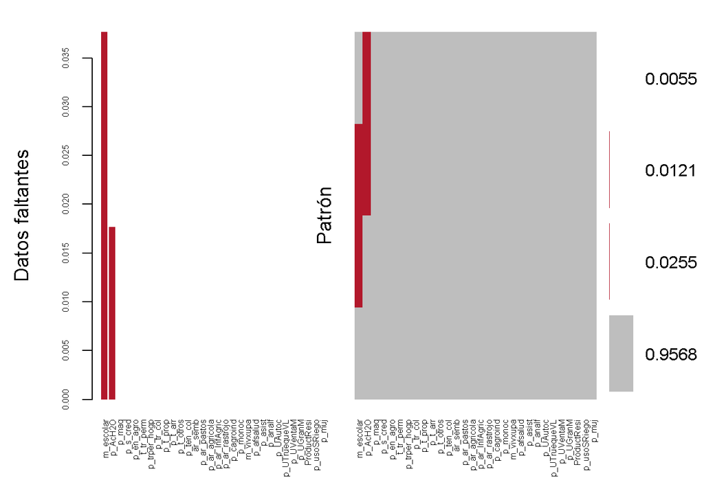

```r
#md<-sapply(filtro1, function(x) sum(length(which(is.na(x)))))
#pander(md[md>0])

# Generando gráfico de datos faltantes
falt<-filtro1[,2:31]
aggr(falt, col=c('grey','#b2182b'), numbers=TRUE, sortVars=TRUE, labels=names(falt), cex.axis=.5, gap=1, ylab=c("Datos faltantes","Patrón"),border=NA)
```

De acuerdo con la salida gráfica del paquete *VIM* El conjunto de datos *filtro1* cuenta con información de 30 variables y 30.138 individuos (veredas) que se encuentra completa en el 95.68% de los casos. En otras palabras, 1.301 veredas no contienen la información de todas las variables. Resalta que 1.135 veredas no tienen datos en la variable “promedio de años de escolaridad”, 532 en la variable “Porcentaje de UPAS con acceso a Agua” y 366 veredas presentan datos faltantes en ambas variables.

Los datos faltantes corresponden a las veredas donde no se respondieron las preguntas asociadas a éstas variables. Las veredas con información faltante se remueven al considerar que solamente representan el 4.31% del total de datos iniciales. El resultado se almacena en un dataframe llamado *filtro2* que se utilizará para el Análisis. Parmanecen 28.837 veredas y 30 variables.

```r
# Removiendo las veredas con datos faltantes
mapa<-subset(filtro1,complete.cases(filtro1))
filtro2<-subset(filtro1,complete.cases(filtro1))

# Removiendo el cod_vereda y asignándolo como nombre de fila
rownames(filtro2)<-filtro2$cod_vereda
filtro2<-filtro2[,c(2:31)]
```

Obtenido el conjunto de datos del 3er CNA para usar en este estudio, se asocia con la capa referencia de veredas del país (disponible en formato *shapefile* en el [geoportal del DANE](https://geoportal.dane.gov.co/veredas/)). Con esta base se genera un mapa con la distribución de las veredas que se van a incluir en el análisis.

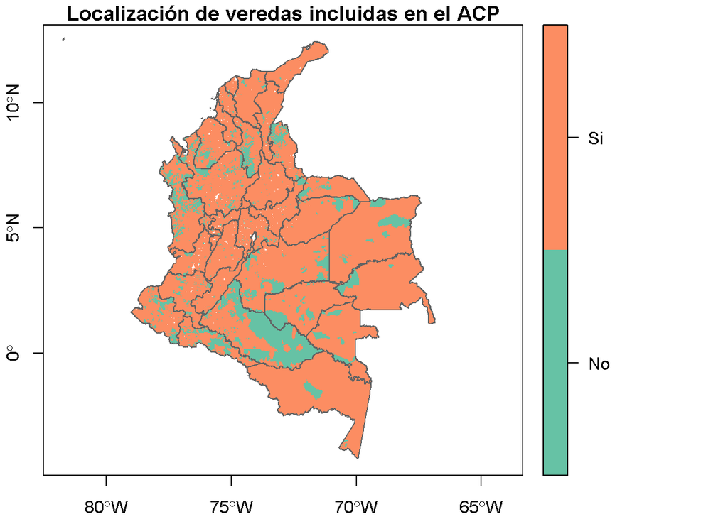

```r
# Leyendo los shapefiles que contienen información geográfica del país en una carpeta local
all_shape_addresses <- list.files(path="E:/VEREDAS_V27", pattern = ".shp", full.names =T, recursive = TRUE)
files_list <- lapply(all_shape_addresses, st_read)
versincl<-files_list[[6]]
departa<-files_list[[1]]
dpt = st_geometry(departa)

# Obteniendo el gráfico de las veredas y sobreponiendo el límite departamental
plot(versincl["Incluida"], border = adjustcolor( "red", alpha.f = 0), axes = TRUE, key.size = lcm(4.5), main = "Localización de veredas incluidas en el ACP")
plot(dpt, add = TRUE, cex = .5, border = "#636363")
```

El mapa muestra en color naranja las veredas que SÍ fueron incluidas en el ACP y, en verde, las que no lo fueron. Una de las causas de esta omisión puede ser que el presente estudio considera únicamente las UPA, pero no las UPNA.

# 3. Análisis preliminar

Para iniciar el análisis, se generan los histogramas de las variables, que representan la distribución de los datos para cada una de ellas. La línea de color azul muestra la mediana, mientras que la función de densidad de los datos aparece de forma sombreada.

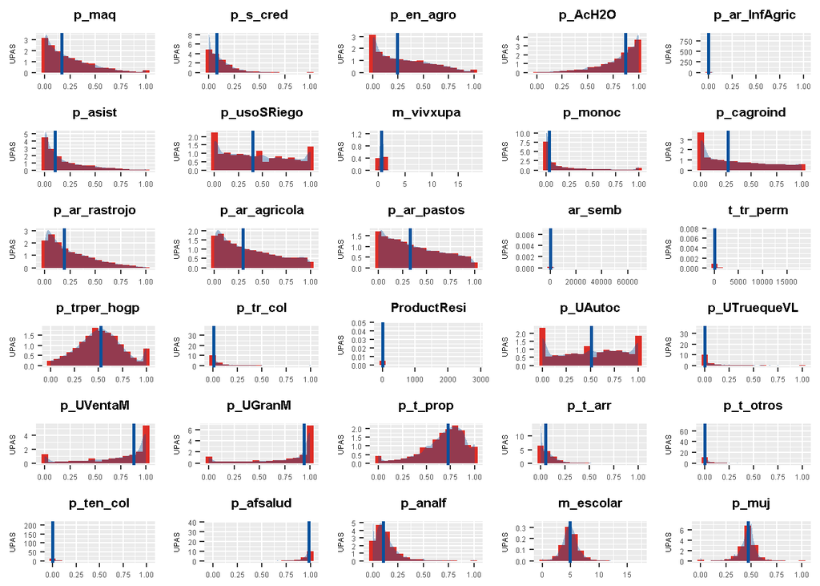

```r
filtro2o<-filtro2[,c(1:3,11,15,21,28,19:16,14:12,4:6,27,23:26,7:10,20,22,29:30)]
a<-names(filtro2o)
a<-as.list(a)
fun02<-function(i){index=grep(i,names(filtro2))
                   bw <- nclass.Sturges(filtro2[,index]) # Freedman-Diaconis
                   nm=paste0(i)
                   assign(paste("g",i,sep=""),
                   ggplot(filtro2, aes(filtro2[,index])) +
                   geom_histogram(bins = bw,aes(y=..density..), fill="#de2d26") +
                   geom_density(alpha=.35, fill="#08519c",color = NA)  +
                   geom_vline (aes(xintercept=median(filtro2[,index])),
            color="#08519c", size=1) +
                   labs(title=nm, x=NULL, y="UPAS")) +
                   theme(plot.title = element_text(size = rel(0.7),face ="bold",hjust = 0.5),
                        axis.title.y = element_text(size = rel(0.4)),
                        axis.text = element_text(size = rel(0.4)))
                   }
Histos<-lapply(a,fun02)
do.call(grid.arrange, Histos)
```

De los histogramas podemos notar el comportamiento de los valores de las variables que entran al análisis:

- El porcentaje de las UPAS por vereda que usa maquinaria que ha solicitado de crédito o asistencia técnica, cuenta con energía agropecuaria tiende a ser bajo, en algunas pocas veredas se puede presentar un alto porcentaje.
- El porcentaje de área en infraestructura agropecuaria es muy bajo y tiende a ser cero en todo el país.
- Las veredas presentan un rango amplio de valores en variables que describen el uso de sistemas de riego.
- Evaluando el uso de monocultivos y cultivos agroindustriales se puede ver que en ambos casos predominan porcentajes bajos, sin embargo, en el caso del monocultivo alrededor del 2% de las veredas presentan solamente monocultivos.
- La proporción de las áreas de pastos, de uso agrícola y de rastrojo es complementaria. Cada una de estas variables presentan una proporción media alrededor del 25% por vereda.
- Se destaca el histograma de la proporción de área sembrada que presenta valores porcentajes muy bajos por vereda.
- El valor de porcentaje de trabajadores permanentes que pertenecen al hogar productor varia por vereda. Caso contrario al de trabajadores permanentes que presenta valores bajos en la mayoría de los casos.
- La proporción de UPAS que producen para el autoconsumo varía en todas las veredas. Los dos extremos, 0% y 100% existe agrupa una cantidad significativa del total de veredas. El análisis espacial permite determinar donde se puede dar este comportamiento.
- Es común encontrar valores altos en la proporción de UPAS con ventas a mercados y grandes mercados. En contraste, la proporción de UPAS que hacen trueque es muy baja en las veredas.
- En la proporción de veredas con trabajo colectivo se encuentran predominantemente valores bajos pero pueden presentar valores altos atípicos.
- La mayoría de veredas presenta una alta proporción de afiliados al sistema de salud.
- Existe una alta proporción de UPAS por vereda con tenencia propia, los otros tipos de tenencia (por arriendo, colectiva y otros tipos de tenencia) presentan valores predominantemente bajos.
- El promedio de años de escolaridad a nivel nacional está cercano a los 5 y encontrar veredas donde el promedio de años de escolaridad sea mayor a 10 años no es común aunque en algunos casos se puede dar. Por su parte, la proporción de analfabetismo es baja en general aunque puede llegar a alcanzar el 50% o valores superiores en casos aislados.
- El dato medio de las veredas analizadas en este estudio presentan una proporción de mujeres cercana al 50%.

También se calculan las correlaciones entre las variables para verificar si algunas de ellas se explican entre sí. La siguiente gráfica muestra una ilustración de la matriz de correlaciones (Para ver el coeficiente de correlación pase el mouse por la celda correspondiente).

```r
# Obteniendo la matriz de correlaciones iniciales
cor_org<-cor(filtro2o)

# Generando representación interactiva de la matriz de correlación
d3heatmap(round(cor_org, 2),symm=TRUE,colors="RdGy",revC=TRUE,dendrogram="none",cexRow=0.6,cexCol=0.6, main="Matriz de correlaciones")
```

[interactive chart not shown]

Esta matriz muestra varias correlaciones lineales entre algunas de las variables:

- Positiva entre:
  - El porcentaje de acceso a agua y el porcentaje de uso de maquinaria.
  - El porcentaje de solicitud de crédito y de asistencia técnica.
  - El porcentaje de solicitud de asistencia técnica y área agrícola.
  - Los porcentajes de tenencia y trabajo colectivo.
  - El número de productores residentes y el área sembrada.
- Negativa entre:
  - El porcentaje de analfabetismo y el promedio de años de escolaridad.
  - El porcentaje de área agrícola y área de pastos

# 4. Análisis de Componentes Principales (ACP)

El análisis estadístico de los datos contempló el cálculo de componentes principales usando el método convencional (matríz de correlaciones) y un método robusto con el fin de evaluar si el efecto de los datos atípicos podría ser minimizado.

## 4.1 ACP Robusto

Se calculan los componentes principales usando el método robusto:

```r
#Componentes robustos
tasas<-filtro2o[,c(colnames(filtro2o)[grepl("p_",colnames(filtro2o))])]
rpc<-princomp(tasas, covmat = MASS::cov.rob(tasas),scores=TRUE)
rpcres<-get_pca(rpc, element = c("var", "ind"))
```

Se genera el gráfico de sedimentación:

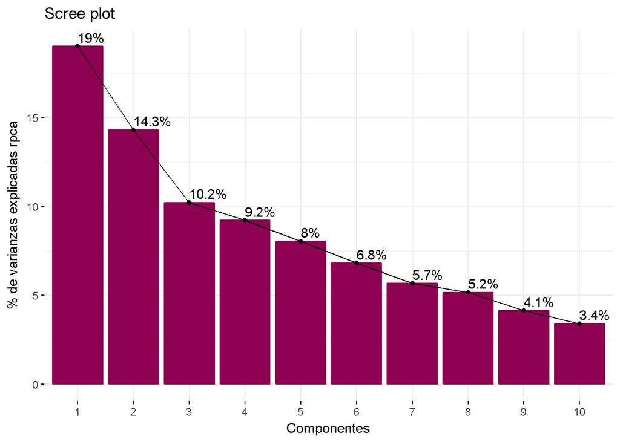

```r
#Scree plot
fviz_eig(rpc,addlabels = TRUE,xlab="Componentes",
         ylab="% de varianzas explicadas rpca",barcolor="#8e0152",barfill="#8e0152")
```

Y la tabla de valores propios y varianza acumulada:

```r
#Tabla de valores propios y varianza acumulada
datatable(round(get_eig(rpc),3), options = list(pageLength = 5))
```

|  | eigenvalue | variance.percent | cumulative.variance.percent |
| --- | --- | --- | --- |
| Dim.1 | 0.19 | 19.014 | 19.014 |
| Dim.2 | 0.143 | 14.302 | 33.317 |
| Dim.3 | 0.102 | 10.227 | 43.544 |
| Dim.4 | 0.092 | 9.224 | 52.768 |
| Dim.5 | 0.08 | 8.044 | 60.811 |
| Dim.6 | 0.068 | 6.815 | 67.626 |
| Dim.7 | 0.057 | 5.673 | 73.299 |
| Dim.8 | 0.052 | 5.175 | 78.474 |
| Dim.9 | 0.041 | 4.143 | 82.617 |
| Dim.10 | 0.034 | 3.409 | 86.026 |

[output cut: 15 more lines]

Los cuatro primeros componentes del ACP robusto retienen el 53% de la varianza de los datos iniciales (variables de porcentaje), sin embargo, ninguno de los valores propios está por encima de 1.

Se generan a continuación los gráficos de: representación de la matriz de correlación entre las variables iniciales y las componentes principales, el círculo de correlaciones del primer plano factorial y un biplot para ver el comportamiento de las veredas frente a las variables.

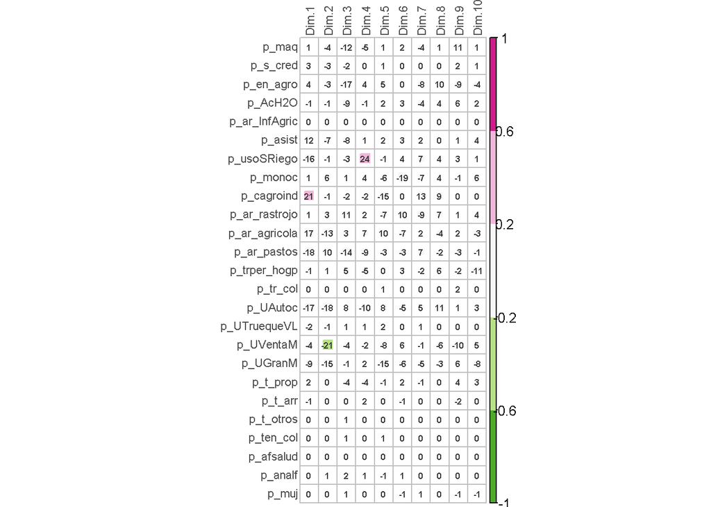

```r
#Representación correlación variable / componente
corrplot(rpcres$cor[,1:10],cex.main=0.7,method = c("square"),number.cex = 0.5,tl.cex=0.7,tl.col="gray31",cl.align="c",tl.offset = 0.1,col = rev(brewer.pal(5, "PiYG")), addCoef.col = "gray22",addCoefasPercent = TRUE)
```

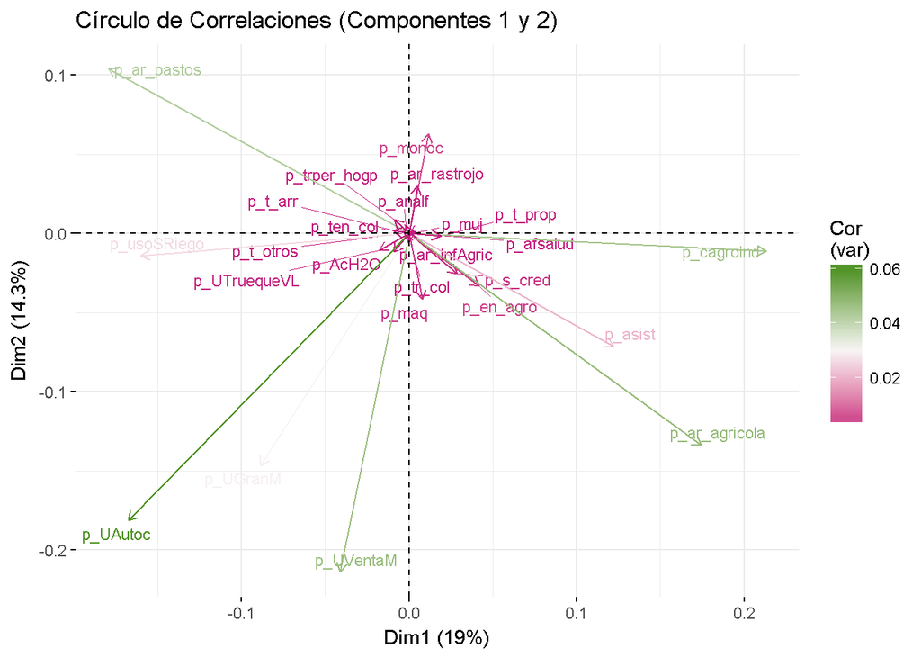

```r
#Círculo de correlaciones
fviz_pca_var(rpc, col.var = "cos2",repel=TRUE,labelsize = 3, gradient.cols = c("#c51b7d", "#f7f7f7", "#4d9221"),title= "Círculo de Correlaciones (Componentes 1 y 2)", legend.title= paste0("Cor",'\n',"(var)"))
```

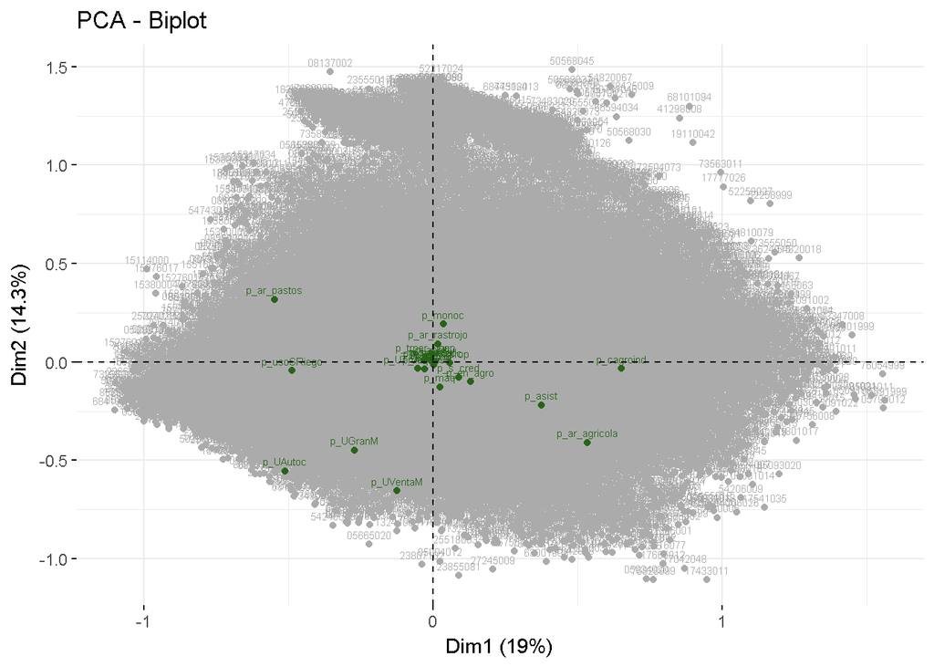

```r
#Biplot
fviz_pca_biplot(rpc,axes=c(1,2), ggtheme = theme_minimal(),labelsize=2,col.ind = "gray67",geom.var = c("point", "text"),pointshape = 19,col.var="#276419")
```

Se puede notar que la representación de las variables es pobre en los componentes robustos. En la matriz de representación se puede observar que ninguna de las variables se representa usando el método robusto. Además, en el círculo de correlaciones ninguna variable, en el primer plano factorial (que retiene el 34% de la varianza de los datos) no alcanza el 7% de correlación. Finalmente, aunque el biplot muestra las variables dentro de la nube de datos de individuos y no se muestran datos atípicos, este método no logra resumir información de las variables.

## 4.2. ACP Convencional

A continuación se calculan los componentes principales del conjunto de datos usando el método convencional (matriz de correlaciones).

```r
pc1<-PCA(filtro2, scale.unit=TRUE,ncp=15,graph=FALSE)
#pcprueba<-princomp(filtro2)
```

Tambien, se calculan los valores propios y el porcentaje de varianza retenida por cada componente.

```r
datatable(round(pc1$eig,3), options = list(pageLength = 5))
```

|  | eigenvalue | percentage of variance | cumulative percentage of variance |
| --- | --- | --- | --- |
| comp 1 | 2.993 | 9.975 | 9.975 |
| comp 2 | 2.723 | 9.077 | 19.053 |
| comp 3 | 2.196 | 7.32 | 26.373 |
| comp 4 | 2.017 | 6.722 | 33.095 |
| comp 5 | 1.674 | 5.579 | 38.675 |
| comp 6 | 1.624 | 5.413 | 44.087 |
| comp 7 | 1.342 | 4.473 | 48.56 |
| comp 8 | 1.208 | 4.028 | 52.588 |
| comp 9 | 1.103 | 3.676 | 56.264 |
| comp 10 | 1.074 | 3.581 | 59.845 |

[output cut: 20 more lines]

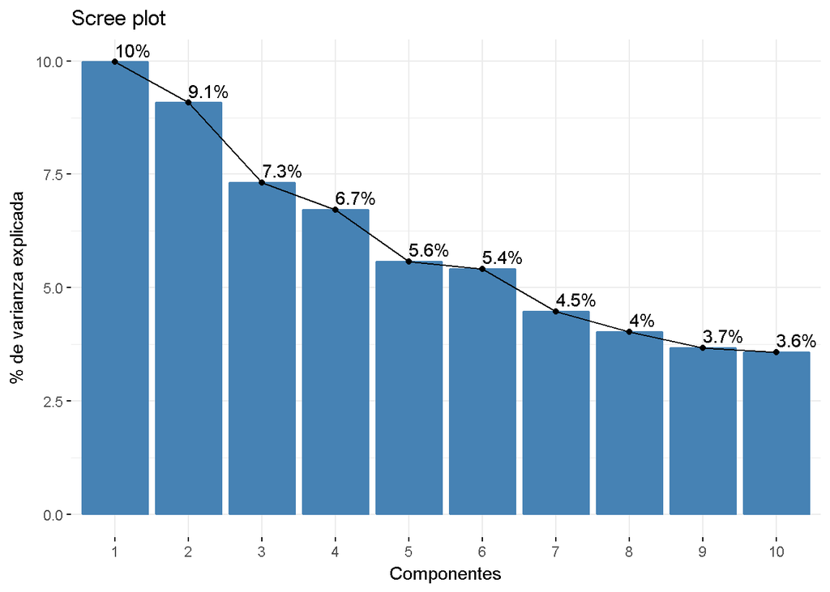

```r
fviz_eig(pc1,addlabels = TRUE,xlab="Componentes",ylab="% de varianza explicada")
```

A continuación se presenta el círculo de correlaciones del primer plano factorial

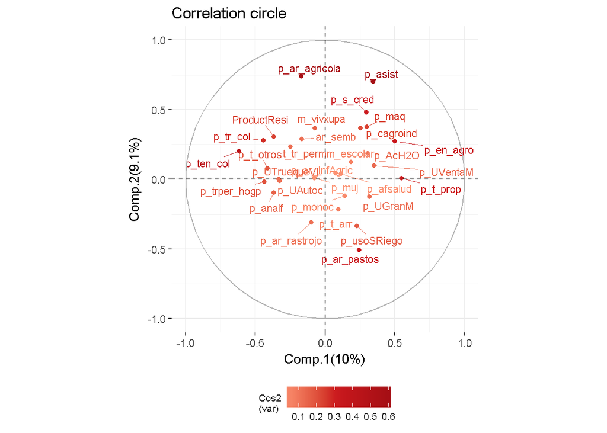

```r
fviz_pca_var(pc1,col.var="cos2",geom=c("point","text"),repel=TRUE,labelsize = 3,gradient.cols = c("#fc9272", "#cb181d", "#a50f15"),title= "Correlation circle", legend.title= paste0("Cos2",'\n',"(var)"), legend=c("bottom"),font.legend = c(8, "plain", "#252525"),xlab="Comp.1(10%)",ylab="Comp.2(9.1%)")
```

Con el fin de evaluar el número de componentes a elegir, tambien se genera el gráfico de correlación de variables con cada una de las componentes principales.

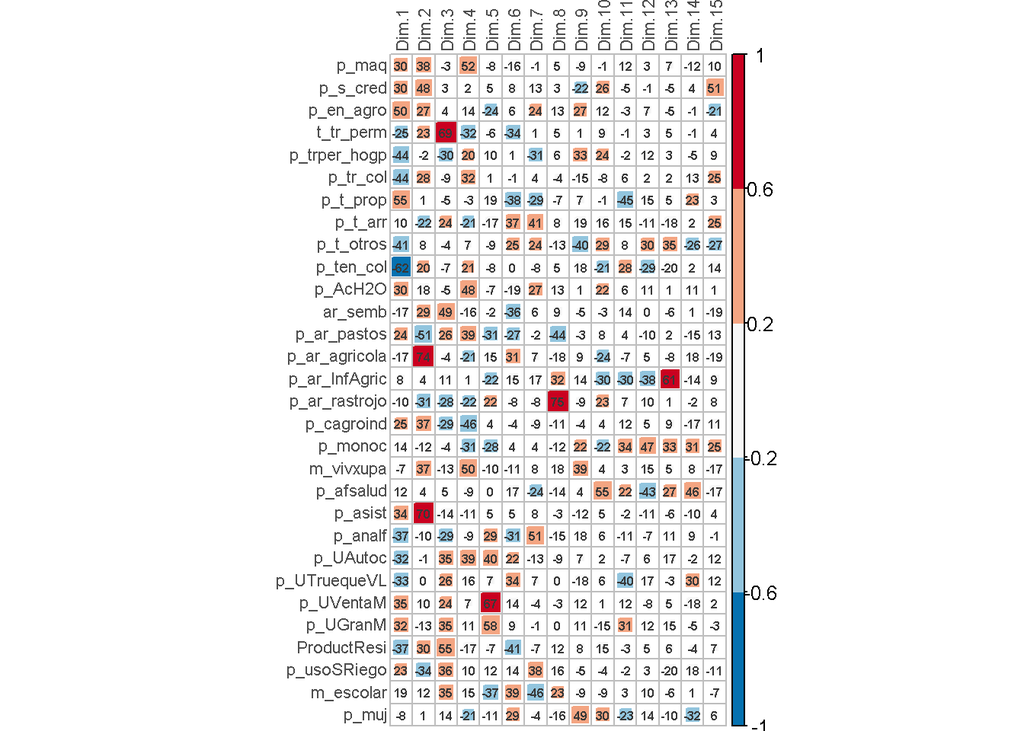

```r
corrplot(pc1$var$cor,cex.main=0.7,method =c("square"),
       number.cex = 0.5,tl.cex=0.7,tl.col="gray31",cl.align="c",tl.offset = 0.1,col = rev(brewer.pal(5, "RdBu")),addCoef.col = "gray22",addCoefasPercent = TRUE)
```

Con base en la información descrita anteriormente, para este estudio, se seleccionaron los primeros cuatro componentes.

### 4.2.1 Calidad general de representación del modelo escogido

La representación de la matriz de correlación de las variables con cada una de las cuatro primeras componentes principales seleccionadas se muestra así:

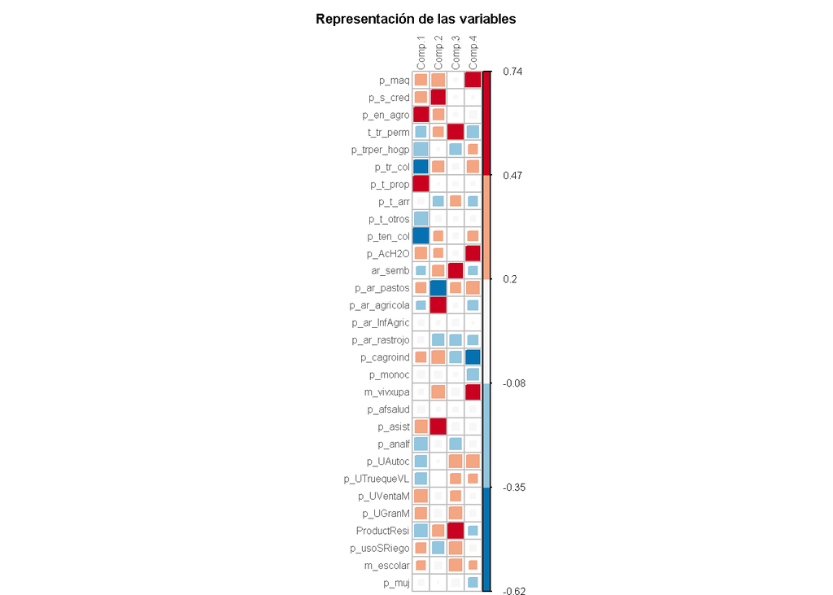

```r
mcor<-pc1$var$cor[,1:4]
colnames(mcor)<-c("Comp.1","Comp.2","Comp.3","Comp.4")
corrplot(mcor,method=c("square"),is.corr=FALSE,number.cex = 0.5,tl.col="gray31",tl.cex=0.5,
       cl.ratio=0.50,cl.cex=0.5, cl.align="l",mar=c(0,0,1.5,0),title="Representación de las variables",cex.main=0.7,col=rev(brewer.pal(5,"RdBu")),cex.main=0.7,tl.offset = 0.1)
```

A mayor intensidad del color y el tamaño de los cuadros mejor correlación entre la variable y la componente.

Otra medida de calidad de representación está relacionado al porcentaje de inercia de la variable que fue retenida por el factor [Pardo et. al. 2009]. La siguiente operación muestra, para los cuatro componentes seleccionadas la medida de calidad de representación por variable incorporada.

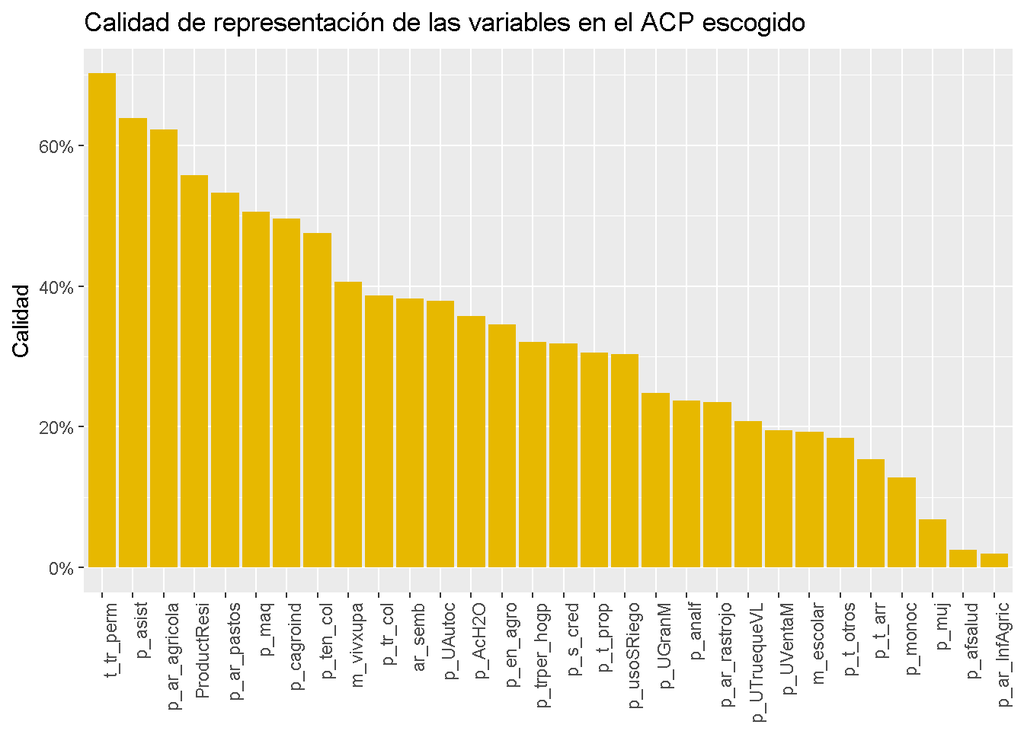

```r
x1 <- t(cumsum(as.data.frame(t(pc1$var$cos2[,1:4]))))
x1 <- as.data.frame(x1[order(-x1[,4]),])
x1$variable <- factor(rownames(x1), levels=rownames(x1)[order(-x1$Dim.4)] )

#barplot(x,las=2,cex.lab=0.5)

p <- ggplot(data=x1, aes(x=variable, y=Dim.4)) +
  geom_bar(stat="identity", fill="#E7B800") +
  scale_y_continuous(labels = scales::percent) +
  theme(
    axis.text.x = element_text(angle = 90, hjust = 1),
    axis.title.x= element_blank()) + labs(title = "Calidad de representación de las variables en el ACP escogido", y = "Calidad")
p
```

Dado que se asume que los factores escogidos son el resumen general de las 30 variables de análisis, éste gráfico permite identificar cuales de las variables tienen mayor y menor relación lineal con el conjunto general de variables.

Las variables total de trabajadores permanentes, porcentaje de asistencia técnica, porcentaje en área agrícola, número de productores residentes, porcentaje de área en pastos y porcentaje de maquinaria tienen una relación con los componentes escogidos superior al 50%.

**4.2.1.1 Calidad de representación por componente**

A continuación se representa la contribución de cada variable en cada uno de los componentes seleccionados. En este caso se dibuja una línea horizontal punteada roja que simboliza el porcentaje promedio de acuerdo al número de variables representadas en el componente.

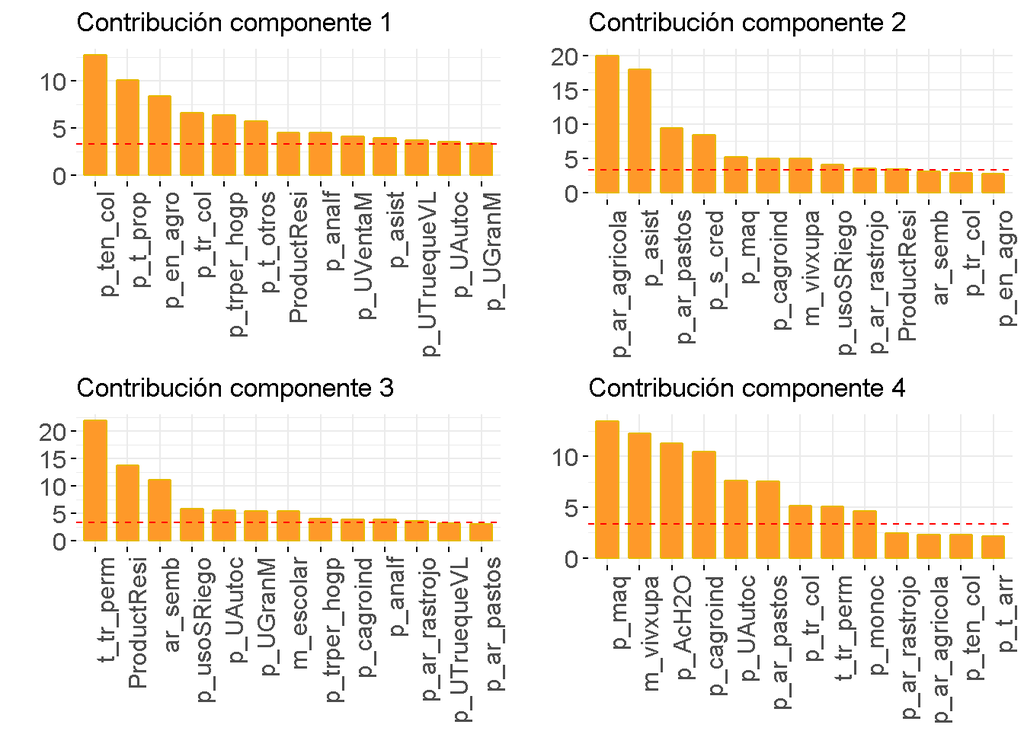

```r
listpl<-list()
for (i in 1:4){
                tmpnm<-paste("varcontComp",i,sep="")
                assign(tmpnm,fviz_contrib(pc1, choice = "var", axes = i, top = 13, fill = "#fe9929",
                                          color = "#E7B800",font.tickslab = c(12),
                                          xtickslab.rt=90)+
                                          labs(title = paste("Contribución componente",i), x = "", y = ""))
                    listpl[[tmpnm]] <- get(tmpnm)
                    }
do.call(grid.arrange, listpl)
```

También, para hacer explícitas las relaciones entre variables y lo que se representa en cada componente seleccionada se genera la matriz de correlación de las variables mejor representadas en cada componente seleccionado.

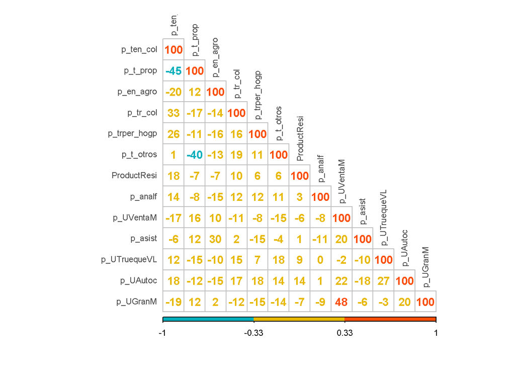

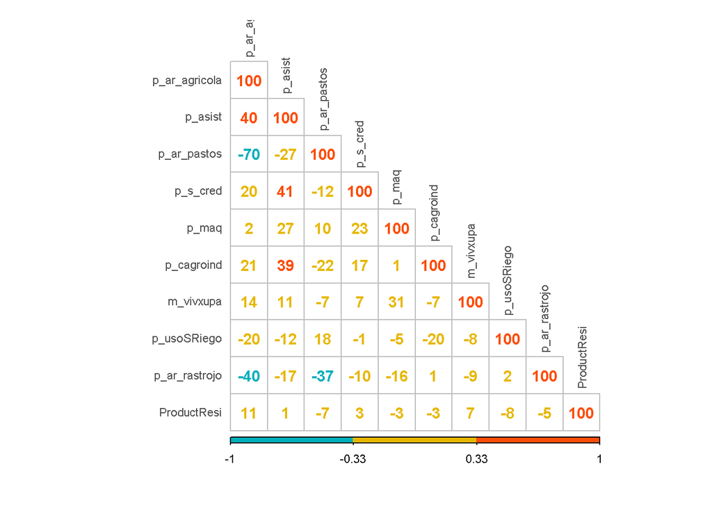

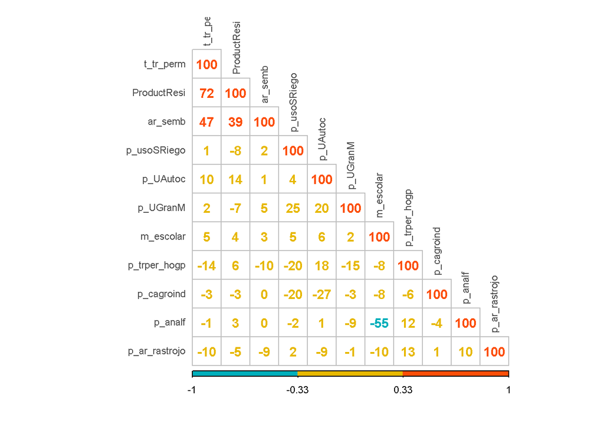

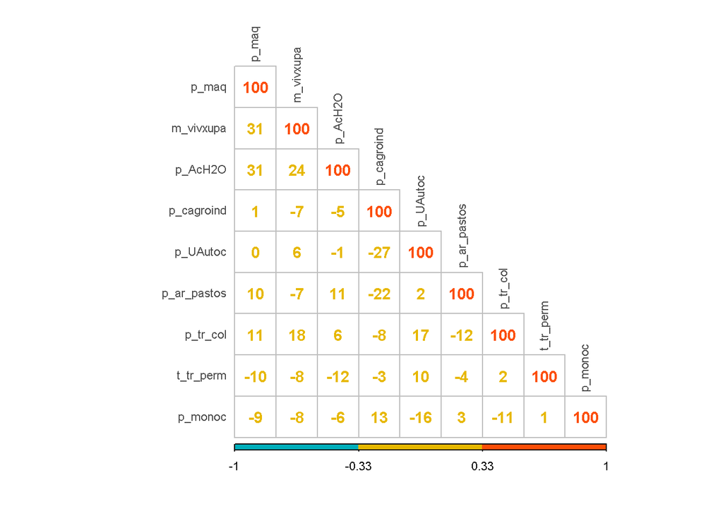

```r
cpsel<-data.frame(pc1$var$contrib[,1:4])
cpsel$Variable<-rownames(cpsel)

long<-melt(cpsel,id.vars="Variable")
long$value<-round(long$value,2)
cpsel2<-split(long,long$variable)

fun03<-function(x){a<-x[order(-x$value),c(1,3)]
                   b<-a[a$value>=(100/30),]}
lcpsel<-lapply(cpsel2,fun03)

colscor<-c("#00AFBB", "#E7B800", "#FC4E07")
fun06<-function(x){nomcp<-x[,1]
                   indi <- match(nomcp, rownames(cor_org))
                   corrplot(round(cor_org[indi,indi],2),method = 'number',
                     addCoefasPercent = TRUE,type="lower",
                     number.cex =0.9,tl.col="gray31",tl.cex=0.7, col=colscor,
                     mar=c(2,0,1,0),oma=c(0,0,0,1),
                     cl.ratio=0.08,cl.cex=0.7,cl.align="l")
                 }
lmcc<-lapply(lcpsel,fun06)
```

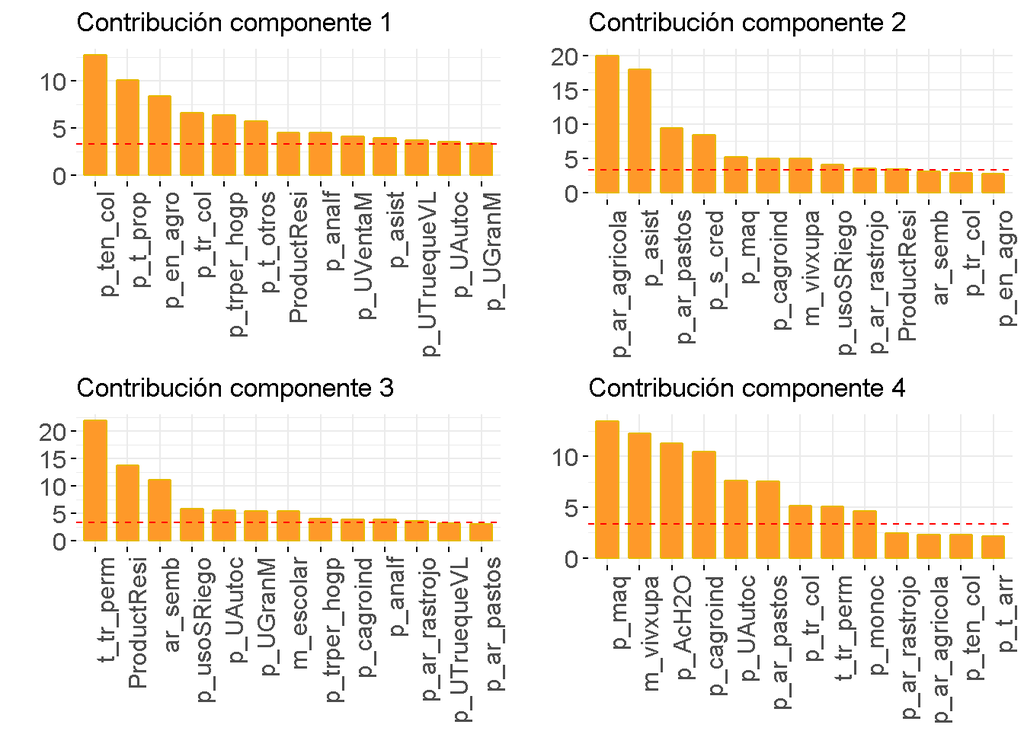

```r
#do.call(grid.arrange,lmcc



listpl<-list()
for (i in 1:4){
                tmpnm<-paste("varcontComp",i,sep="")
                assign(tmpnm,fviz_contrib(pc1, choice = "var", axes = i, top = 13, fill = "#fe9929",
                                          color = "#E7B800",font.tickslab = c(12),
                                          xtickslab.rt=90)+
                                          labs(title = paste("Contribución componente",i), x = "", y = ""))
                    listpl[[tmpnm]] <- get(tmpnm)
                    }
do.call(grid.arrange, listpl)
```

Finalmente, se muestran los círculos de correlación para cada combinación de componentes principales.

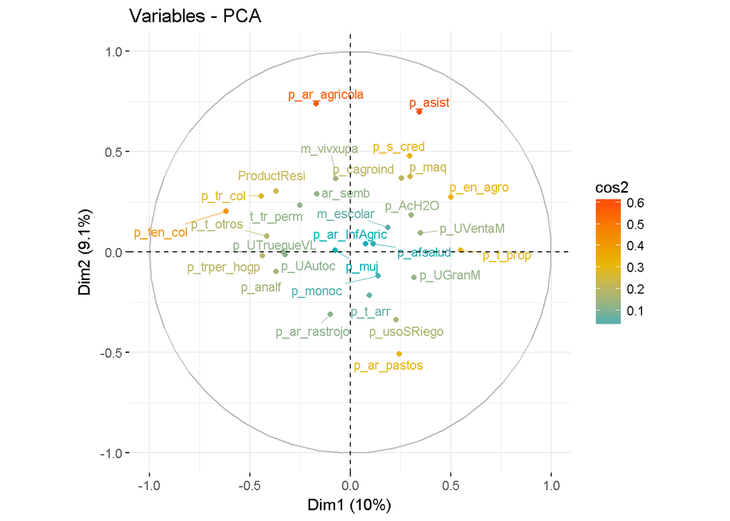

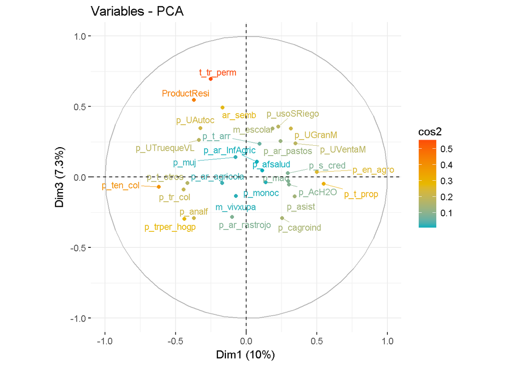

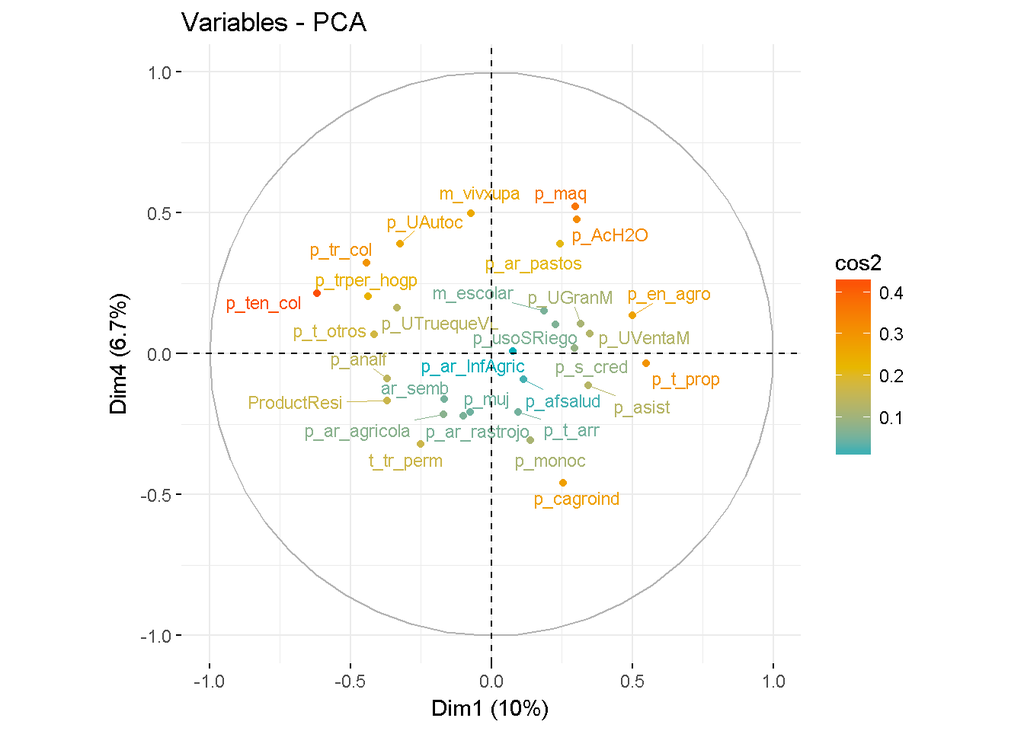

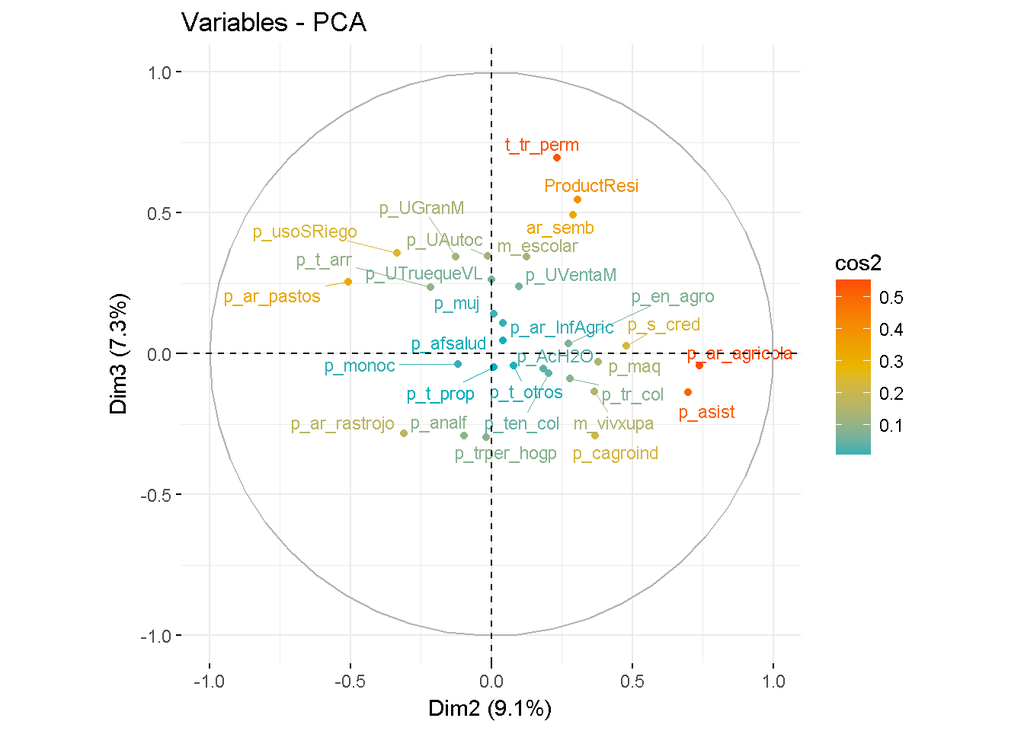

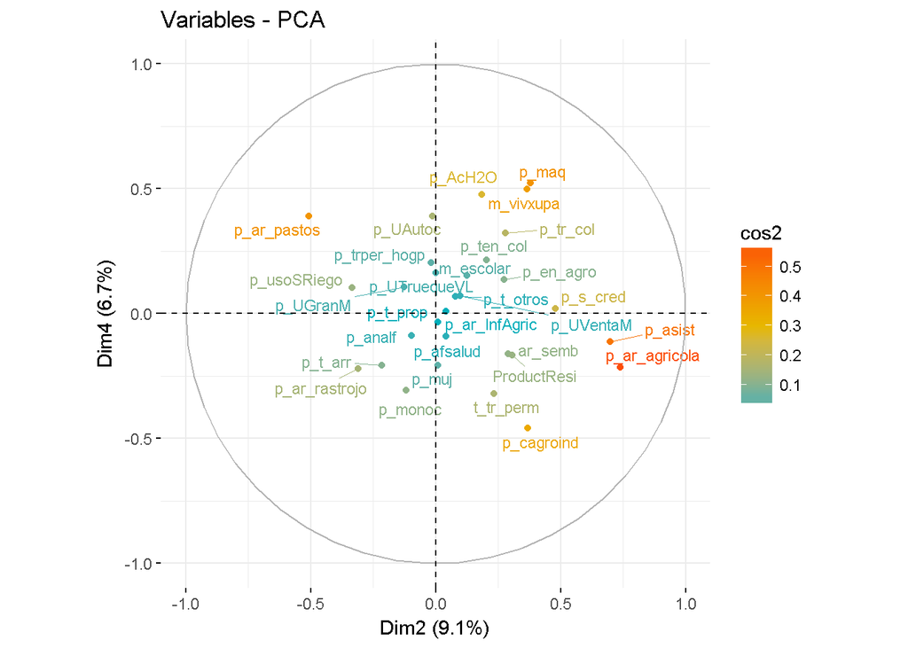

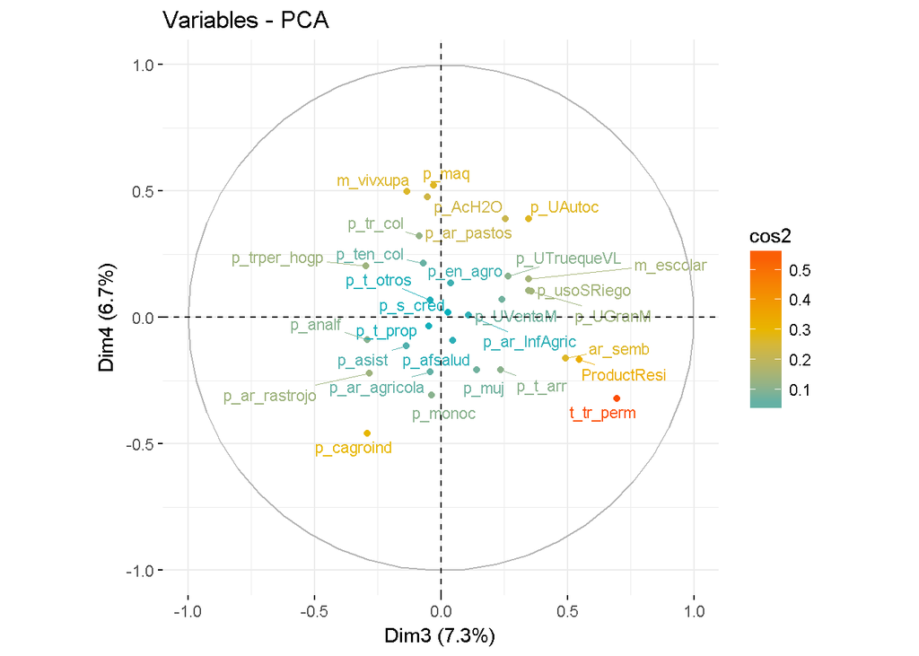

En este caso, aunque no es práctica la utilización de biplots para la interpretación de los resultados, al ser cuatro componentes se obliga a que se haga una lectura de 3 espacios factoriales de 3dsimensiones o a 6 planos factoriales de 2 dimensiones. Por esto se ha optado, para una mayor facilidad: tipificar, caracterizar y perfilar las variables dentro de cada componente con su lectura individual (tal y como en el análisis de Carlos).

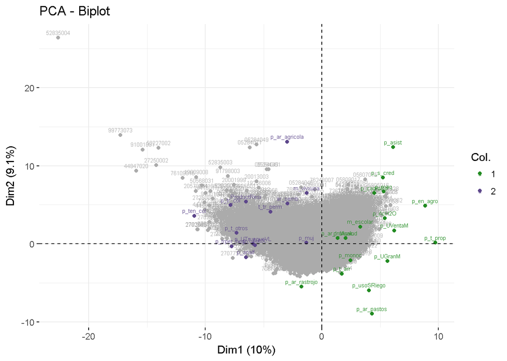

```r
scv<- scale(pc1$var$coord)
set.seed(1)
vcoordcl <- kmeans(pc1$var$coord, centers = 2, nstart = 40)
grp <- as.factor(vcoordcl$cluster)

fviz_pca_biplot(pc1,axes=c(1,2), col.var=grp,palette = c("#228B22", "#5D478B"),ggtheme = theme_minimal(),labelsize=2,col.ind = "gray67",geom.var = c("point", "text"),pointshape = 19)
```

## Referencias

- *Geometría euclidiana en estadística: métodos en ejes principales*. Pardo, C.E. Consultado en: http://www.docentes.unal.edu.co/cepardot/docs/Conferencias/ACPgeometriaEuclidiana.pdf. Fecha: Noviembre de 2017.
- *Principal Component Methods in R: Practical Guide*. Kassambara A. Consultado en: http://www.sthda.com/english/articles/31-principal-component-methods-in-r-practical-guide/112-pca-principal-component-analysis-essentials/. Fecha: Noviembre de 2017.